# EDA buscas

Aluna: Marcela Tassyany Galdino Santos

Este relatório tem como objetivo expor uma análise exploratória dos dados fornecidos pela Wikimedia Foundation que vem de um esquema de rastreamento, usados para avaliar a satisfação do usuário. A análise realizada se dará com o intuito de responder quatro questionamentos pré-estabelecidos e que serão exibidos nas próximas seções.

```r
library(tidyverse)
library(here)
library(lubridate)
library(viridis)
library(grid)
library(gridExtra)
theme_set(theme_bw())
```

```r
buscas = read_csv(here::here("data/search_data.csv"))  %>%
    mutate(day = round_date(session_start_date, unit = "day"))
#cliques/numero de sessoes
buscas2 = buscas %>%
    mutate(clicks = num_clicks > 0)%>%
    mutate(zeroResults = results == 0)
buscas3 = buscas2 %>%
    group_by(session_id) %>%
    summarise(
    max_search_index = max(search_index),
    click = max(clicks),
    zeroResult = sum(zeroResults),
    day = max(day),
    zero_results_prop = (zeroResult / max_search_index),
    group = max(group),
    session_length = max(session_length)
    )
```

# 1. Qual é a nossa taxa de cliques geral diária? Como isso varia entre os grupos?

Para responder essa pergunta será usado principalmente as variáveis num_clicks que retorna O número de páginas que o usuário visitou a partir da busca e da variável group que divide o conjunto de dados em dois grupos: A e B (não se tem mais informações sobre do que se trata cada um desses grupos). Primeiramente, é necessário avaliar a distribuição de cada uma dessas variaveis.

Analisando a variável group, nota-se que o grupo B é maior que o grupo A (uma diferença de 9111). As características desses grupos poderiam explicar o motivo dessa diferença, no entanto, não se tem acesso a essa informação. Nesse sentido, deve-se levar em consideração que os resultados podem sofrer influência dessa diferença entre os grupos.

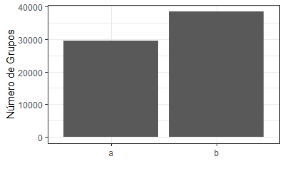

```r
buscas %>%
   distinct(session_id, .keep_all=TRUE) %>%
ggplot() +
  geom_bar(mapping = aes(x = group), stat = "count")  + labs(y="Número de Grupos", x="")
```

```r
buscas %>%
    distinct(session_id, .keep_all=TRUE) %>%
    summarise(TamanhoA = length(which(group=="a")),
TamanhoB = length(which(group=="b")))
```

| TamanhoA | TamanhoB |
| --- | --- |
| 29420 | 38531 |

Quanto a variável num_clicks, observando o histograma nota-se que a maioria dos dados estão concentrados a esquerda indicando que uma distribuição assimétrica positiva (positive skew), o que é confirmado pelo fato da média ser maior que a mediana. É possível também observar uma cauda à direita, esse comportamento indica a presença de valores discrepantes, o que é confirmado pelo alto desvio padrão apresentado.

```r
buscas %>%
    ggplot(aes(x = num_clicks)) +
    geom_histogram(bins = 20, fill = "white", color = "blue")  + geom_rug(alpha = .3) + labs(y =
    "Frequência", x = "Número de Cliques")


getmode <- function(v) {
   uniqv <- unique(v)
   uniqv[which.max(tabulate(match(v, uniqv)))]
}

buscas %>%
    summarise(
    Media = mean(num_clicks),
    Mediana = median(num_clicks),
    Moda = getmode(num_clicks),
    Desvio = sd(num_clicks),
    Minimo = min(num_clicks),
    Maximo = max(num_clicks),
    )
```

[output not shown]

Analisando a distribuição de número de cliques por grupos, é possível observar que tanto para o grupo A como para o grupo B há uma maior ocorrência de 0 e 1 cliques. No entanto, nota-se uma maior variação nos dados do grupo A, em que o valor máximo chega a 36 cliques, se comparado ao grupo B em que o valor máximo foi de 3 cliques.

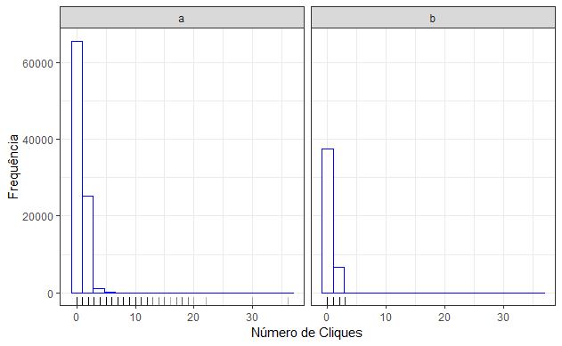

```r
buscas %>%
    ggplot(aes(x = num_clicks)) +
    geom_histogram(bins = 20, fill = "white", color = "blue")  + geom_rug(alpha = .3) + labs(y =
    "Frequência", x = "Número de Cliques") + facet_wrap(~ group)
```

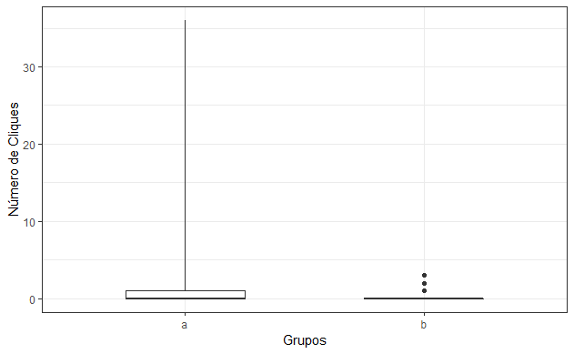

```r
ggplot(buscas, mapping = aes(x = group, y = num_clicks))   +
  geom_boxplot(coef = 1000, width = .5) + labs(y="Número de Cliques", x="Grupos")
```

```r
buscas %>%
    group_by(group)%>%
    summarise(
    Media = mean(num_clicks),
    Mediana = median(num_clicks),
    Moda = getmode(num_clicks),
    Desvio = sd(num_clicks),
    Minimo = min(num_clicks),
    Maximo = max(num_clicks),
    Total_de_Cliques = sum(num_clicks),
    Total_de_Buscas = sum(search_index)
    )
```

| group | Media | Mediana | Moda | Desvio | Minimo | Maximo | Total_de_Cliques | Total_de_Buscas |
| --- | --- | --- | --- | --- | --- | --- | --- | --- |
| a | 0.3609759 | 0 | 0 | 0.7451162 | 0 | 36 | 33230 | 556956 |
| b | 0.1535380 | 0 | 0 | 0.3663022 | 0 | 3 | 6783 | 50599 |

Para calcular a taxa de cliques, foi criada a variável num_clicks_prop que retorna a proporção de sessões de pesquisa em que o usuário clicou em um dos resultados exibidos. Para calcular essa taxa se contabilizava 1 para a ocorrência de pelo menos 1 clique por sessão, e se efetuava a razão entre essa soma e o total de sessões por dia.

Por meio do gráfico abaixo e das medidas de sumarização dos dados, é possível observar que há uma variação na taxa de cliques ao longo dos dias, mas essa diferença não é tão evidente e chega a ser no máximo de 1,77% considerando a diferença entre o maior e menor valor apresentado. Os resultados dão indícios que em média a taxa de cliques é de 38,8%. durante os dias.

```r
clickthrough_rate_all = buscas3 %>%
    group_by(day) %>%
    summarise(num_clicks_prop = (sum(click)/length(session_id)*100))


clickthrough_rate_all  %>% mutate(day = day(day)) %>%
    mutate(day = factor(day, levels = c("1", "2", "3", "4", "5", "6", "7", "8", "9"))) %>%
    ggplot(clickthrough_rate_all,
    mapping = aes(x = day, y = num_clicks_prop)) + geom_point(size = 3, colour="red") +  labs(y = "Taxa de Cliques", x = "Dias")


clickthrough_rate_all %>%
    summarise(
    Media = mean(num_clicks_prop),
    Mediana = median(num_clicks_prop),
    Desvio = sd(num_clicks_prop),
    Minimo = min(num_clicks_prop),
    Maximo = max(num_clicks_prop)
    )
```

[output not shown]

```r
buscas_group_a = buscas3 %>%
    filter(group == 'a')

buscas_group_b = buscas3 %>%
    filter(group == 'b')


clickthroughrate_b = buscas_group_b %>%
    group_by(day) %>%
    summarise(num_clicks_prop = (sum(click)/length(session_id))*100,

              group = "b")

clickthroughrate_a = buscas_group_a %>%
    group_by(day) %>%
    summarise(num_clicks_prop = (sum(click)/length(session_id))*100,
              group = "a")

clickthrough_rate = rbind(clickthroughrate_a, clickthroughrate_b)




clickthrough_rate  %>% mutate(day = day(day)) %>%
    mutate(day = factor(day, levels = c("1", "2", "3", "4", "5", "6", "7", "8", "9"))) %>%
    ggplot(clickthrough_rate,
    mapping = aes(x = day, y = num_clicks_prop, colour = group))  + geom_point(size = 2) + geom_line(aes(group =
    group), size = 0.5) + labs(y = "Taxa de Cliques", x = "Dias", colour = "Grupo")

    ggplot(clickthrough_rate, mapping = aes(x = group, y = num_clicks_prop))   +
  geom_boxplot(coef = 1000, width = .5) + labs(y="Taxa de Cliques", x="Grupos")


clickthrough_rate %>%
    group_by(group) %>%
    summarise(
    Media = mean(num_clicks_prop),
    Mediana = median(num_clicks_prop),
    Desvio = sd(num_clicks_prop),
    Minimo = min(num_clicks_prop),
    Maximo = max(num_clicks_prop)
    )
```

[output not shown]